# Desafio Data Science

Henrique C Vieira

Junho 4, 2018

# Analisando os dados bank

O dado **Bank Marketing** foi obtido do repositório de datasets [https://archive.ics.uci.edu](https://archive.ics.uci.edu/ml/datasets/bank+marketing)

Link para download: bank.zip

#### Carregando bibliotecas a serem usadas nesse projeto.

```r
library(dplyr, warn.conflicts=FALSE, verbose=FALSE)
library(ggplot2, warn.conflicts=FALSE, verbose=FALSE)
library(tidyr, warn.conflicts=FALSE, verbose=FALSE)
library(readr, warn.conflicts=FALSE, verbose=FALSE)
library(FSelector)
```

### Introdução

Este é um dado relacionado com as campanhas de marketing de uma instuição bancária de Portugal. São campanhas baseadas em ligações telefônicas para oferecer aos clientes o serviço de depósito a prazo fixo (bank term deposit), onde poderão retirar o valor após o prazo ter vencido.

O termo term deposit: A term deposit is a fixed-term deposit held at a financial institution. They are generally short-term deposits with maturities ranging anywhere from a month to a few years. When a term deposit is purchased, the client understands that the money can only be withdrawn after the term has ended or by giving a predetermined number of days notice. [Investopedia](https://www.investopedia.com/terms/t/termdeposit.asp)

[Moro et al., 2011] S. Moro, R. Laureano and P. Cortez. Using Data Mining for Bank Direct Marketing: An Application of the CRISP-DM Methodology. In P. Novais et al. (Eds.), Proceedings of the European Simulation and Modelling Conference - ESM’2011, pp. 117-121, Guimarães, Portugal, October, 2011. EUROSIS.

Available at: [pdf] http://hdl.handle.net/1822/14838 [bib] http://www3.dsi.uminho.pt/pcortez/bib/2011-esm-1.txt

### Carregando o dataset bank

Utilizaremos o pacote readr, que permite carregar dados em formato csv e tsv mais rápido que as funções básicas do R para carregar dados.

```r
dataset <- read_delim('bank/bank.csv', delim = ';')
glimpse(dataset)
```

```
## Observations: 4,521
## Variables: 17
## $ age       <int> 30, 33, 35, 30, 59, 35, 36, 39, 41, 43, 39, 43, 36, ...
## $ job       <chr> "unemployed", "services", "management", "management"...
## $ marital   <chr> "married", "married", "single", "married", "married"...
## $ education <chr> "primary", "secondary", "tertiary", "tertiary", "sec...
## $ default   <chr> "no", "no", "no", "no", "no", "no", "no", "no", "no"...
## $ balance   <int> 1787, 4789, 1350, 1476, 0, 747, 307, 147, 221, -88, ...
## $ housing   <chr> "no", "yes", "yes", "yes", "yes", "no", "yes", "yes"...
## $ loan      <chr> "no", "yes", "no", "yes", "no", "no", "no", "no", "n...
## $ contact   <chr> "cellular", "cellular", "cellular", "unknown", "unkn...
## $ day       <int> 19, 11, 16, 3, 5, 23, 14, 6, 14, 17, 20, 17, 13, 30,...
## $ month     <chr> "oct", "may", "apr", "jun", "may", "feb", "may", "ma...
## $ duration  <int> 79, 220, 185, 199, 226, 141, 341, 151, 57, 313, 273,...
## $ campaign  <int> 1, 1, 1, 4, 1, 2, 1, 2, 2, 1, 1, 2, 2, 1, 1, 2, 5, 1...
## $ pdays     <int> -1, 339, 330, -1, -1, 176, 330, -1, -1, 147, -1, -1,...
## $ previous  <int> 0, 4, 1, 0, 0, 3, 2, 0, 0, 2, 0, 0, 0, 0, 1, 0, 0, 2...
## $ poutcome  <chr> "unknown", "failure", "failure", "unknown", "unknown...
## $ y         <chr> "no", "no", "no", "no", "no", "no", "no", "no", "no"...
```

### Alterando o tipo da coluna para o tipo correto

Alterando as colunas do tipo texto para colunas do tipo categórico, em R são do tipo factor. As colunas com valores ‘yes’ e ‘no’ foram transfomadas em valores lógicos TRUE e FALSE.

```r
dataset$job <- as.factor(dataset$job)
dataset$marital <- as.factor(dataset$marital)
dataset$education <- as.factor(dataset$education)
dataset$default <- ifelse(dataset$default == 'yes', TRUE, FALSE)
dataset$housing <- ifelse(dataset$housing == 'yes', TRUE, FALSE)
dataset$loan <- ifelse(dataset$loan == 'yes', TRUE, FALSE)
dataset$contact <- as.factor(dataset$contact)
dataset$day <- as.factor(dataset$day)
dataset$month <- as.factor(dataset$month)
dataset$campaign <- as.factor(dataset$campaign)
dataset$poutcome <- as.factor(dataset$poutcome)
dataset$y <- ifelse(dataset$y == 'yes', TRUE, FALSE)
dataset$term <- dataset$y
glimpse(dataset)
```

```
## Observations: 4,521
## Variables: 18
## $ age       <int> 30, 33, 35, 30, 59, 35, 36, 39, 41, 43, 39, 43, 36, ...
## $ job       <fctr> unemployed, services, management, management, blue-...
## $ marital   <fctr> married, married, single, married, married, single,...
## $ education <fctr> primary, secondary, tertiary, tertiary, secondary, ...
## $ default   <lgl> FALSE, FALSE, FALSE, FALSE, FALSE, FALSE, FALSE, FAL...
## $ balance   <int> 1787, 4789, 1350, 1476, 0, 747, 307, 147, 221, -88, ...
## $ housing   <lgl> FALSE, TRUE, TRUE, TRUE, TRUE, FALSE, TRUE, TRUE, TR...
## $ loan      <lgl> FALSE, TRUE, FALSE, TRUE, FALSE, FALSE, FALSE, FALSE...
## $ contact   <fctr> cellular, cellular, cellular, unknown, unknown, cel...
## $ day       <fctr> 19, 11, 16, 3, 5, 23, 14, 6, 14, 17, 20, 17, 13, 30...
## $ month     <fctr> oct, may, apr, jun, may, feb, may, may, may, apr, m...
## $ duration  <int> 79, 220, 185, 199, 226, 141, 341, 151, 57, 313, 273,...
## $ campaign  <fctr> 1, 1, 1, 4, 1, 2, 1, 2, 2, 1, 1, 2, 2, 1, 1, 2, 5, ...
## $ pdays     <int> -1, 339, 330, -1, -1, 176, 330, -1, -1, 147, -1, -1,...
## $ previous  <int> 0, 4, 1, 0, 0, 3, 2, 0, 0, 2, 0, 0, 0, 0, 1, 0, 0, 2...
## $ poutcome  <fctr> unknown, failure, failure, unknown, unknown, failur...
## $ y         <lgl> FALSE, FALSE, FALSE, FALSE, FALSE, FALSE, FALSE, FAL...
## $ term      <lgl> FALSE, FALSE, FALSE, FALSE, FALSE, FALSE, FALSE, FAL...
```

### Sumarização dos dados

Podemos observar abaixo, os valores de minimo, máximo, 1º, 2º (mediana) e 3º quartil e a média para dados númericos e a contagem individual para cada valor para os dados categóricos.

Podemos perceber um grande desbalanceamento dos dados.

```r
dataset %>%
  summary()
```

```
##       age                 job          marital         education
##  Min.   :19.00   management :969   divorced: 528   primary  : 678
##  1st Qu.:33.00   blue-collar:946   married :2797   secondary:2306
##  Median :39.00   technician :768   single  :1196   tertiary :1350
##  Mean   :41.17   admin.     :478                   unknown  : 187
##  3rd Qu.:49.00   services   :417
##  Max.   :87.00   retired    :230
##                  (Other)    :713
##   default           balance       housing           loan
##  Mode :logical   Min.   :-3313   Mode :logical   Mode :logical
##  FALSE:4445      1st Qu.:   69   FALSE:1962      FALSE:3830
##  TRUE :76        Median :  444   TRUE :2559      TRUE :691
##                  Mean   : 1423
##                  3rd Qu.: 1480
##                  Max.   :71188
##
##       contact          day           month         duration
##  cellular :2896   20     : 257   may    :1398   Min.   :   4
##  telephone: 301   18     : 226   jul    : 706   1st Qu.: 104
##  unknown  :1324   19     : 201   aug    : 633   Median : 185
##                   21     : 198   jun    : 531   Mean   : 264
##                   14     : 195   nov    : 389   3rd Qu.: 329
##                   17     : 191   apr    : 293   Max.   :3025
##                   (Other):3253   (Other): 571
##     campaign        pdays           previous          poutcome
##  1      :1734   Min.   : -1.00   Min.   : 0.0000   failure: 490
##  2      :1264   1st Qu.: -1.00   1st Qu.: 0.0000   other  : 197
##  3      : 558   Median : -1.00   Median : 0.0000   success: 129
##  4      : 325   Mean   : 39.77   Mean   : 0.5426   unknown:3705
##  5      : 167   3rd Qu.: -1.00   3rd Qu.: 0.0000
##  6      : 155   Max.   :871.00   Max.   :25.0000
##  (Other): 318
##      y              term
##  Mode :logical   Mode :logical
##  FALSE:4000      FALSE:4000
##  TRUE :521       TRUE :521
##
##
##
##
```

### Relações dos dados e gráficos

#### Número de individuos pela ocupação profissional e estado civil.

```r
dataset %>%
  group_by(job) %>%
  count(marital, sort = TRUE)
```

```
## # A tibble: 35 x 3
## # Groups:   job [12]
##            job marital     n
##         <fctr>  <fctr> <int>
##  1 blue-collar married   693
##  2  management married   557
##  3  technician married   411
##  4  management  single   293
##  5  technician  single   268
##  6      admin. married   266
##  7    services married   236
##  8     retired married   176
##  9 blue-collar  single   174
## 10      admin.  single   143
## # ... with 25 more rows
```

#### Número total de sucessos por campanha

```r
dataset %>%
  group_by(poutcome) %>%
  count(campaign, sort = TRUE)
```

```
## # A tibble: 59 x 3
## # Groups:   poutcome [4]
##    poutcome campaign     n
##      <fctr>   <fctr> <int>
##  1  unknown        1  1309
##  2  unknown        2  1057
##  3  unknown        3   474
##  4  unknown        4   288
##  5  failure        1   263
##  6  unknown        5   147
##  7  unknown        6   137
##  8  failure        2   131
##  9    other        1    88
## 10  success        1    74
## # ... with 49 more rows
```

#### Número de individuos por nível escolar

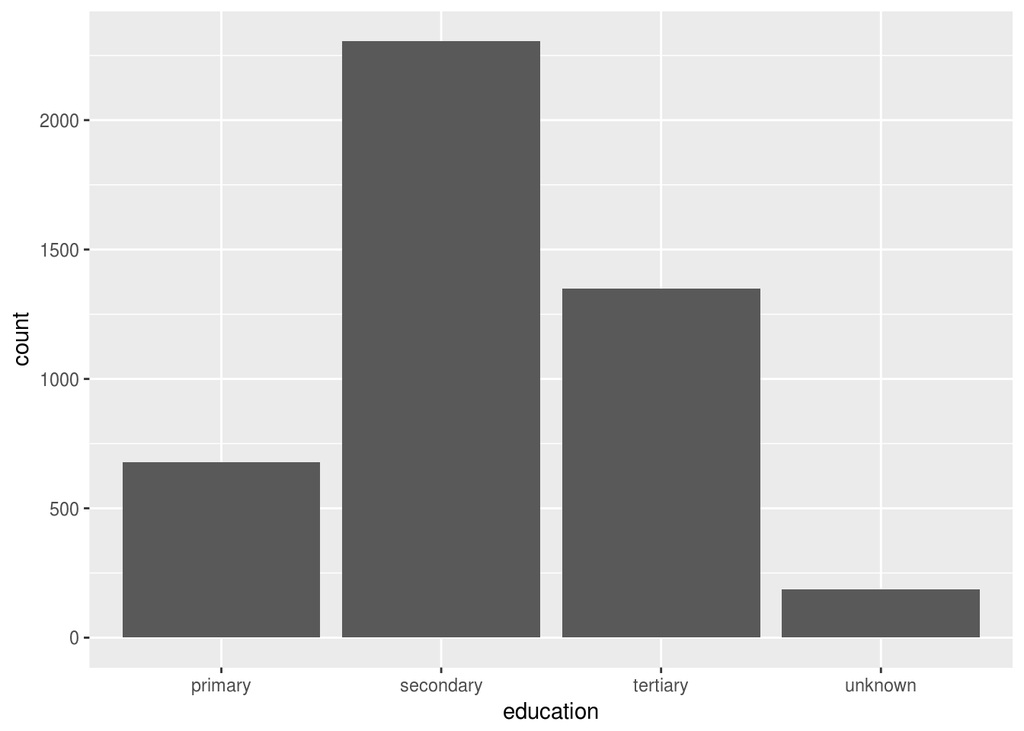

```r
ggplot(dataset, aes(x=education)) +
  geom_bar()
```

#### Número de individuos pela ocupação profissional

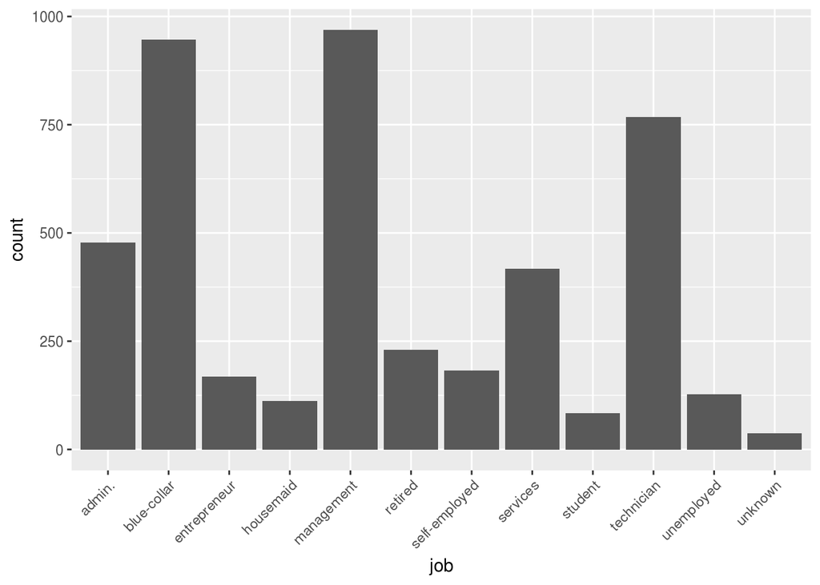

```r
ggplot(dataset, aes(x=job)) +
  geom_bar() +
  theme(axis.text.x = element_text(angle = 45, hjust = 1))
```

#### Distribuição da idade

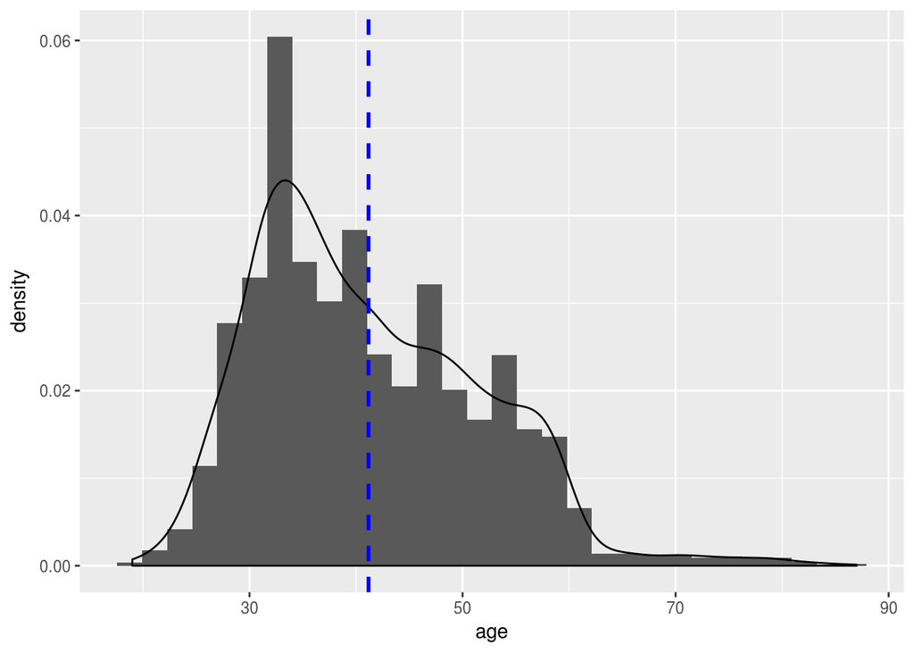

```r
ggplot(dataset, aes(x=age, y=..density..)) +
  geom_histogram() +
  geom_density() +
  geom_vline(aes(xintercept=mean(age)),
            color="blue", linetype="dashed", size=1)
```

#### Relação entre ocupação profissional e a idade

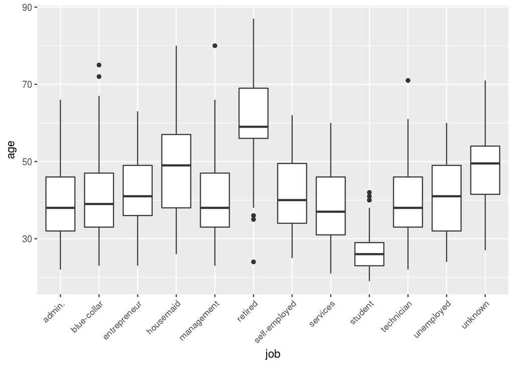

```r
ggplot(dataset, aes(x=job, y=age)) +
  geom_boxplot() +
  theme(axis.text.x = element_text(angle = 45, hjust = 1))
```

#### Número de contratos assinados na campanha anterior

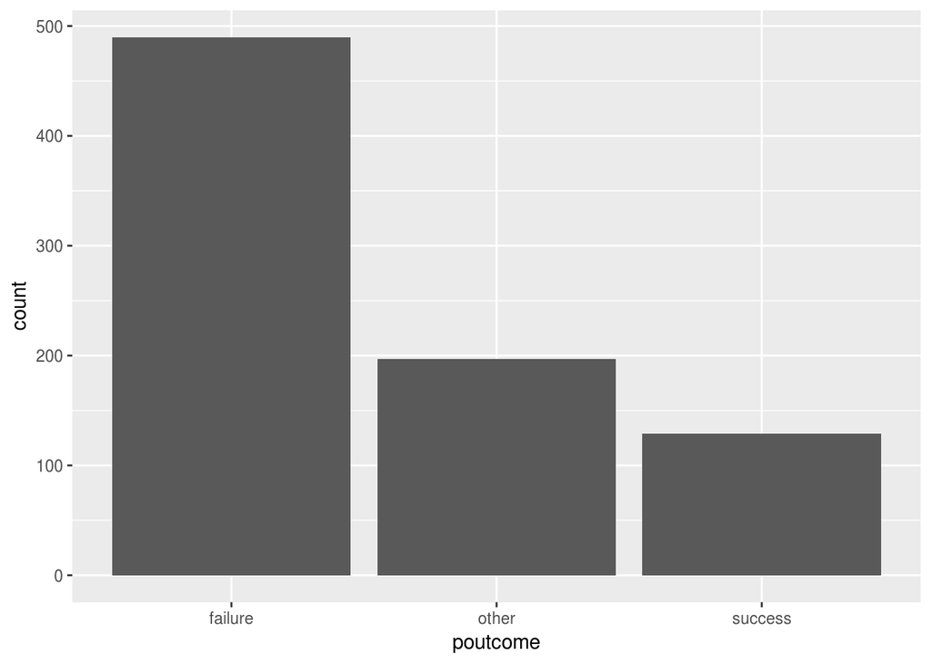

```r
dataset %>%
  filter(poutcome != 'unknown') %>%
  ggplot(aes(x=poutcome)) +
  geom_bar()
```

#### Número de contatos pela campanha anterior e estado (sucesso, falha e outros)

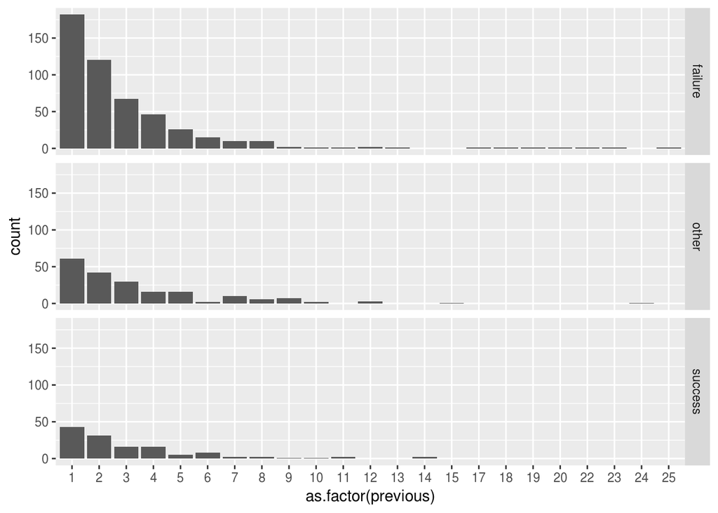

```r
dataset %>%
  filter(poutcome != 'unknown') %>%
  ggplot(aes(x=as.factor(previous))) +
  geom_bar() +
  facet_grid(poutcome ~ .)
```

# Respondendo as questões:

### 1. Qual profissão tem mais tendência a fazer um empréstimo? De qual tipo?

**Visualizando as profissões por empréstimo**

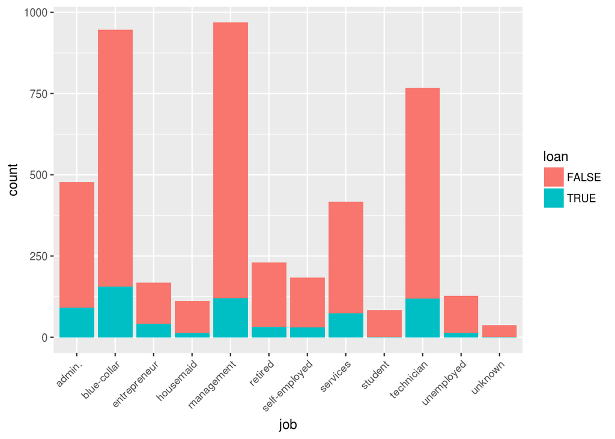

```r
ggplot(dataset, aes(x=job, fill=loan)) +
  geom_bar() +
  theme(axis.text.x = element_text(angle = 45, hjust = 1))
```

**Visualizando as profissões por empréstimo imobiliário**

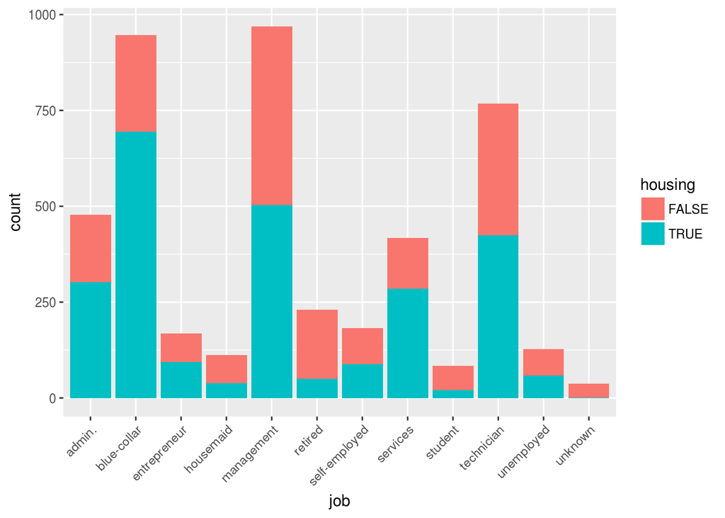

```r
ggplot(dataset, aes(x=job, fill=housing)) +
  geom_bar() +
  theme(axis.text.x = element_text(angle = 45, hjust = 1))
```

Como podemos observar pelos dois gráficos, o blue-collar e management são as duas profissões que mais se destacam. Vamos filtrar por essas duas profissões e analisar qual apresentar o maior número de empréstimos e de qual tipo.

```r
dataset %>%
  filter(loan == TRUE | housing == TRUE) %>%
  filter(job == 'blue-collar' | job == 'management') %>%
  count(job, loan, housing)
```

```
## # A tibble: 6 x 4
##           job  loan housing     n
##        <fctr> <lgl>   <lgl> <int>
## 1 blue-collar FALSE    TRUE   592
## 2 blue-collar  TRUE   FALSE    53
## 3 blue-collar  TRUE    TRUE   103
## 4  management FALSE    TRUE   442
## 5  management  TRUE   FALSE    59
## 6  management  TRUE    TRUE    61
```

blue-collar é a profissão que mais realiza empréstimos e do tipo housing.

### 2. Fazendo uma relação entre número de contatos e sucesso da campanha quais são os pontos relevantes a serem observados?

No gráfico abaixo vemos o resultado da campanha anterior.

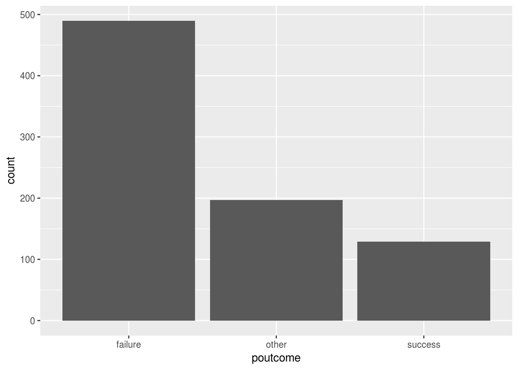

```r
dataset %>%
  filter(poutcome != 'unknown') %>%
  ggplot(aes(x=poutcome)) +
  geom_bar()
```

```r
dataset %>%
  filter(poutcome == "success") %>%
  count(previous, sort = TRUE)
```

```
## # A tibble: 12 x 2
##    previous     n
##       <int> <int>
##  1        1    43
##  2        2    31
##  3        3    16
##  4        4    16
##  5        6     8
##  6        5     5
##  7        7     2
##  8        8     2
##  9       11     2
## 10       14     2
## 11        9     1
## 12       10     1
```

Temos um grande numero de falhas na campanha anterior. Os contatos onde obtiveram sucesso se destacaram realizando de 1, 2, 3 ou até 4 contatos com o cliente. A partir de 6 ligações há um número menor de clientes que mudam de opinião e passam aderem.

### 3. Baseando-se nos resultados de adesão desta campanha qual o número médio e o máximo de ligações que você indica para otimizar a adesão?

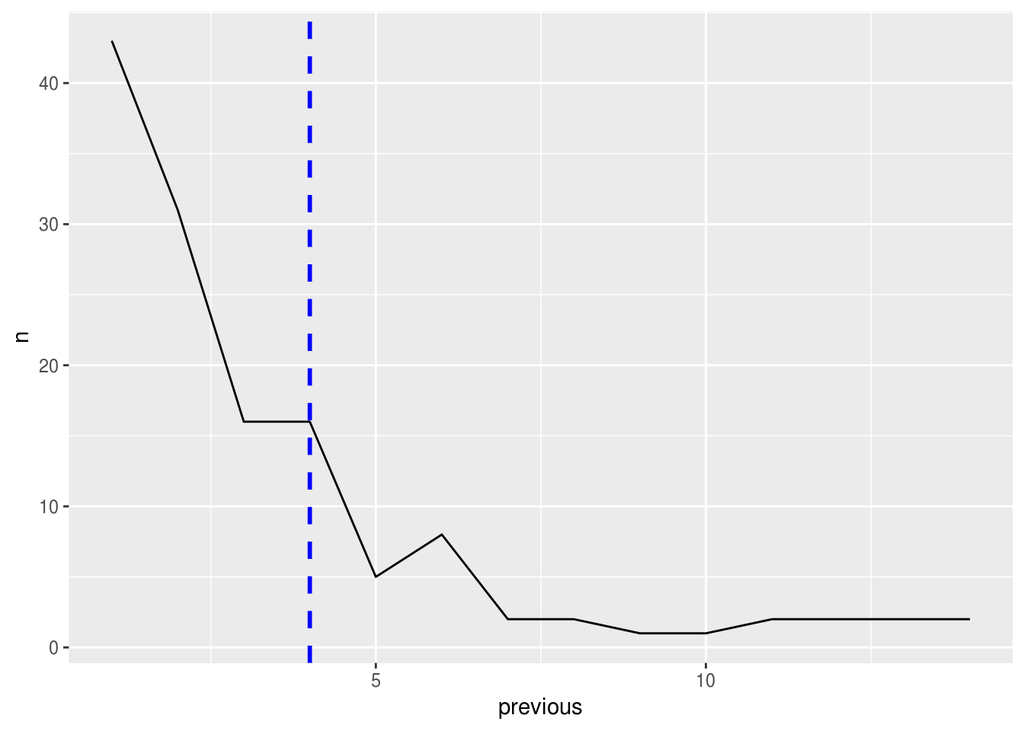

```r
dataset %>%
  filter(poutcome == "success") %>%
  count(previous, sort = TRUE) %>%
  ggplot(aes(x=previous, y=n)) +
  geom_line() +
  geom_vline(aes(xintercept=4),
            color="blue", linetype="dashed", size=1)
```

Observandoo gráfico acima, podemos perceber que há uma queda muito grande a partir de 5 ligações, sugiro em média 2 ligações e no máximo 4 para maximizar a adesão de novos clientes.

### 4. O resultado da campanha anterior tem relevância na campanha atual?

```r
table(dataset$poutcome, dataset$term)
```

```
##
##           FALSE TRUE
##   failure   427   63
##   other     159   38
##   success    46   83
##   unknown  3368  337
```

### 5. Qual o fator determinante para que o banco exija um seguro de crédito?

Segundo a pagina [euler hermes](http://www.eulerhermes.com.br/pt/seguro-de-credito/conhecimento/Pages/o-que-e-seguro-de-credito.aspx):

“O seguro de crédito protege o seu negócio contra o não pagamento da dívida de transações comerciais.”

Os clientes inadimplentes, identificado pela categoria ‘default’, tendem a criar novas dívidas, para estes clientes, deverá ser exigido o seguro de crédito. Neste dados temos poucos inadimplentes, como visto no gráfico abaixo.

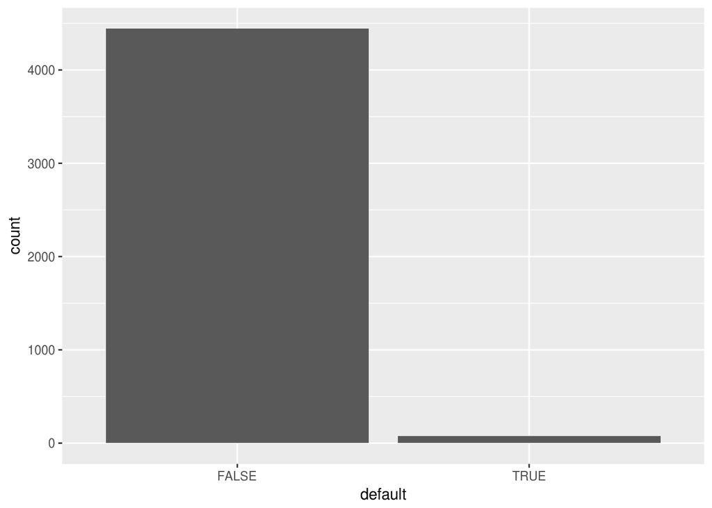

```r
ggplot(dataset, aes(x=default)) +
  geom_bar()
```

### 6. Quais são as características mais proeminentes de um cliente que possua empréstimo imobiliário?

Utilizamos o V de Cramer para calcular a relação entre as caracteristicas. Quanto mais proximo de 1, indica uma relação mais forte entre as caracteristicas observadas.

```r
housing_result <- chi.squared(housing ~ ., dataset)
housing_result
```

```
##           attr_importance
## age           0.236825273
## job           0.289918963
## marital       0.042755530
## education     0.124149204
## default       0.006880645
## balance       0.136269860
## loan          0.018450768
## contact       0.218924768
## day           0.171232332
## month         0.490185378
## duration      0.000000000
## campaign      0.086134127
## pdays         0.154704795
## previous      0.000000000
## poutcome      0.135471994
## y             0.104683400
## term          0.104683400
```

Usaremos aqui a função cutoff.k que irá selecionar as 6 caracteristicas com valor de V de Cramer mais alto.

```r
cutoff.k(housing_result, 6)
```

```
## [1] "month"   "job"     "age"     "contact" "day"     "pdays"
```

Descartando as caracteristicas “month”, “contact”, “day” e “pdays”, pois não são relacionadas diretamente ao perfil cliente, temos então “job” (emprego) e “age” (idade) como fatores principais que caracterizam um cliente com empréstimo imobiliário.

# Predição

Usando tecnicas de aprendizado de maquina, vamos substituir os valores ‘unknown’ por valores preditos.

```r
library(rpart)
library(naivebayes)
```

### Job

```r
job_unknown <- dataset$job == 'unknown'
dataset_job_real <- dataset[!job_unknown,]
dataset_job_unknown <- dataset[job_unknown,]
dataset_job_real$job <- droplevels(dataset_job_real$job)
dataset_job_unknown <- dataset_job_unknown[, colnames(dataset_job_unknown) != 'job']
```

```r
job_model <- rpart(job ~ age+marital, dataset_job_real, method = 'class')
```

```r
job_pred <- predict(job_model, dataset_job_unknown, type='class')
```

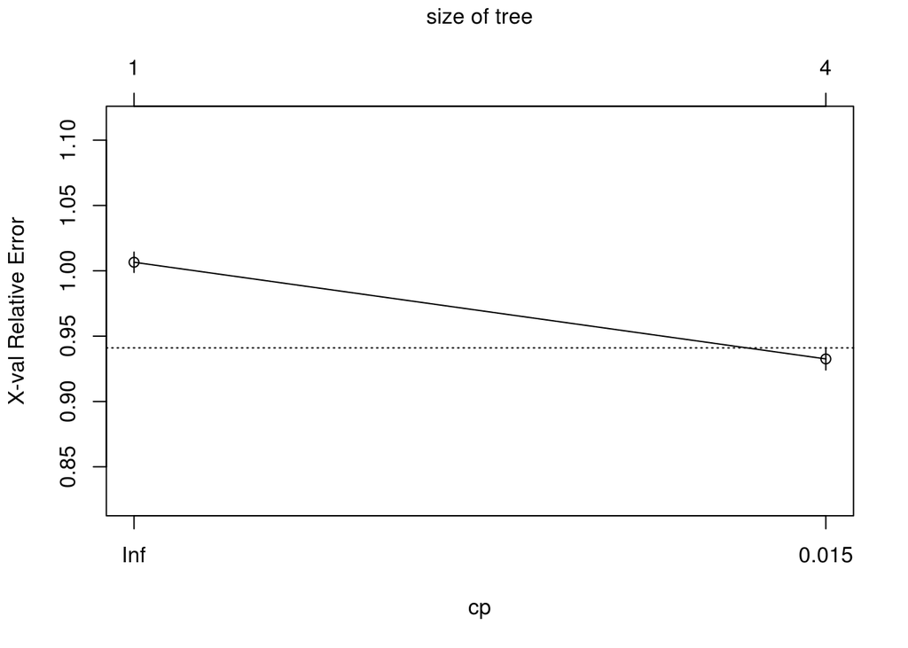

```r
plotcp(job_model)
```

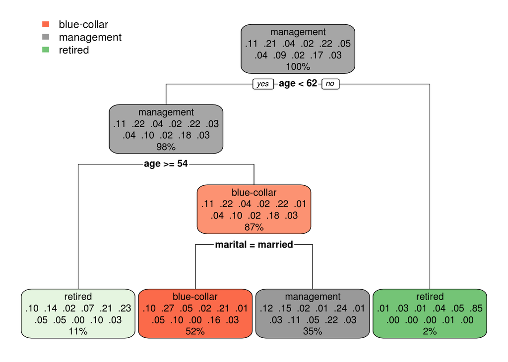

```r
rpart.plot::rpart.plot(job_model)
```

### Inserindo os valores preditos na caracteristica ‘job’

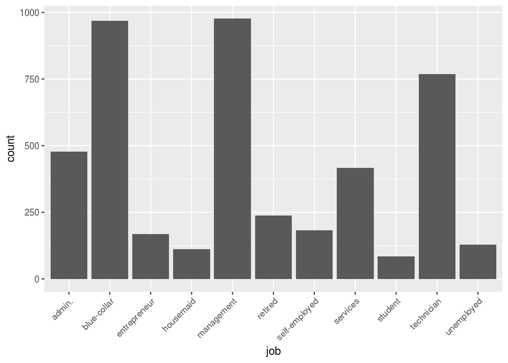

```r
dataset$job[job_unknown] <- job_pred
dataset$job <- droplevels(dataset$job)
ggplot(dataset, aes(x=job)) +
  geom_bar() +
  theme(axis.text.x = element_text(angle = 45, hjust = 1))
```

### Education

```r
education_unknown <- dataset$education == 'unknown'
dataset_education_real <- dataset[!education_unknown,]
dataset_education_unknown <- dataset[education_unknown,]
dataset_education_real$education <- droplevels(dataset_education_real$education)
dataset_education_unknown <- dataset_education_unknown[, colnames(dataset_education_unknown) != 'education']
```

```r
education_model <- rpart(education ~ age+marital+job, dataset_education_real, method = 'class')
```

```r
education_pred <- predict(education_model, dataset_education_unknown, type='class')
```

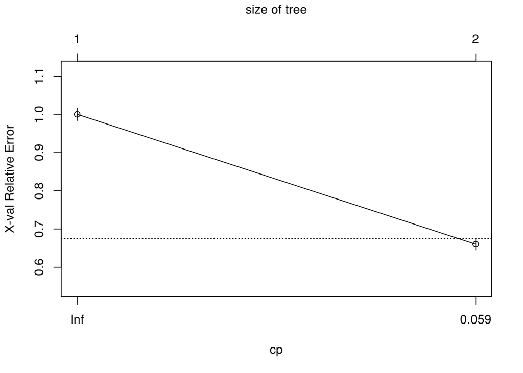

```r
plotcp(education_model)
```

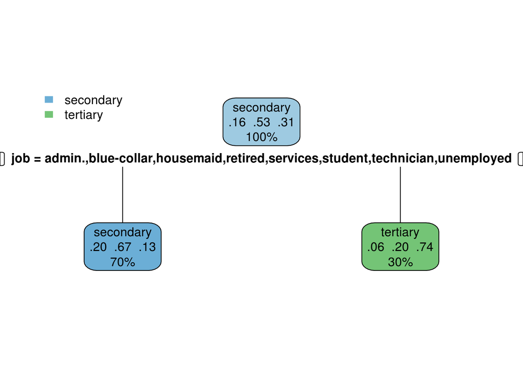

```r
rpart.plot::rpart.plot(education_model)
```

### Inserindo os valores preditos na caracteristica ‘education’

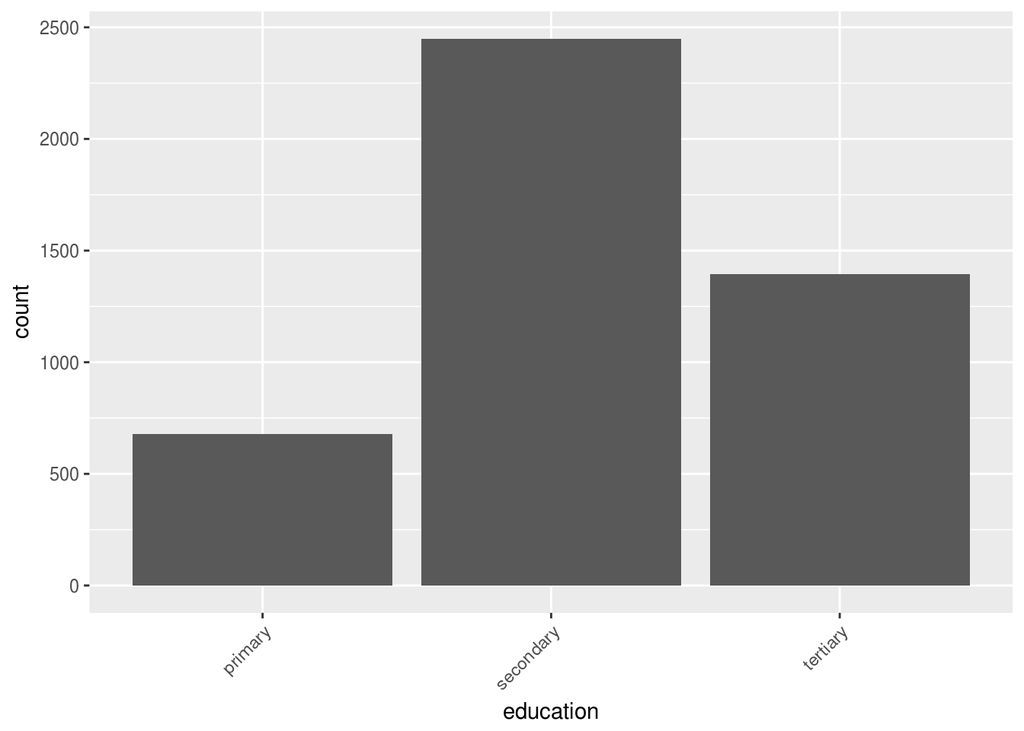

```r
dataset$education[education_unknown] <- education_pred
dataset$education <- droplevels(dataset$education)
ggplot(dataset, aes(x=education)) +
  geom_bar() +
  theme(axis.text.x = element_text(angle = 45, hjust = 1))
```

# Poutcome

```r
poutcome_unknown <- dataset$poutcome == 'unknown'
dataset_poutcome_real <- dataset[!poutcome_unknown,]
dataset_poutcome_unknown <- dataset[poutcome_unknown,]
dataset_poutcome_real$poutcome <- droplevels(dataset_poutcome_real$poutcome)
dataset_poutcome_unknown <- dataset_poutcome_unknown[, colnames(dataset_poutcome_unknown) != 'poutcome']
```

```r
poutcome_model <- rpart(poutcome ~ age+marital+job+default+housing+loan+campaign, dataset_poutcome_real, method = 'class')
```

```r
poutcome_pred <- predict(poutcome_model, dataset_poutcome_unknown, type='class')
```

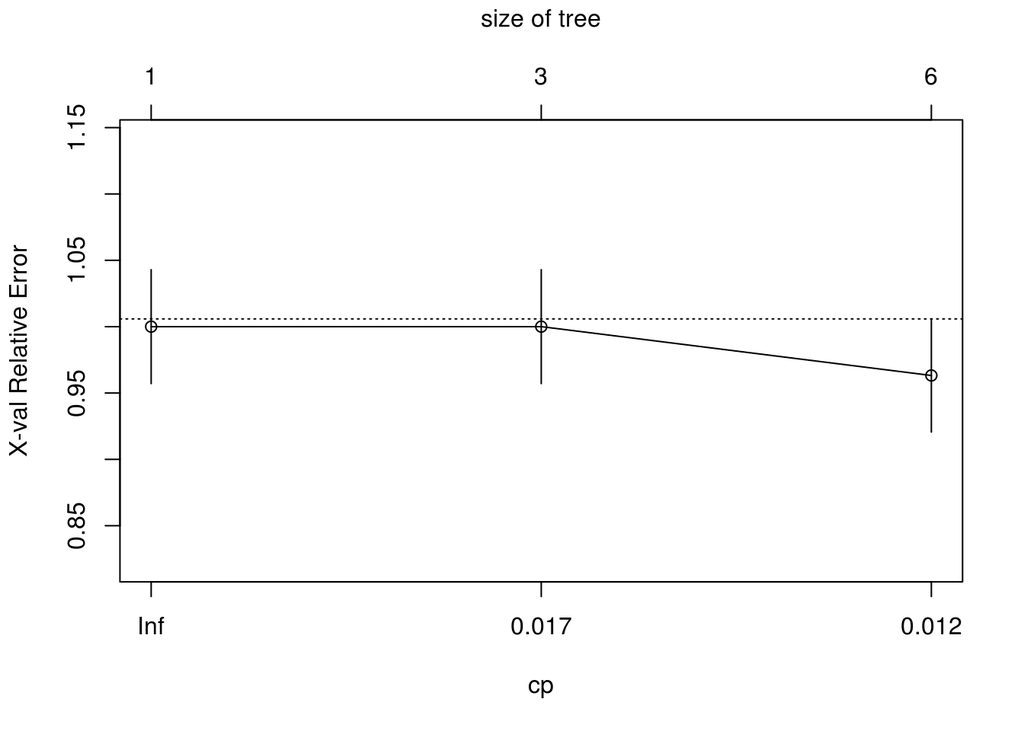

```r
plotcp(poutcome_model)
```

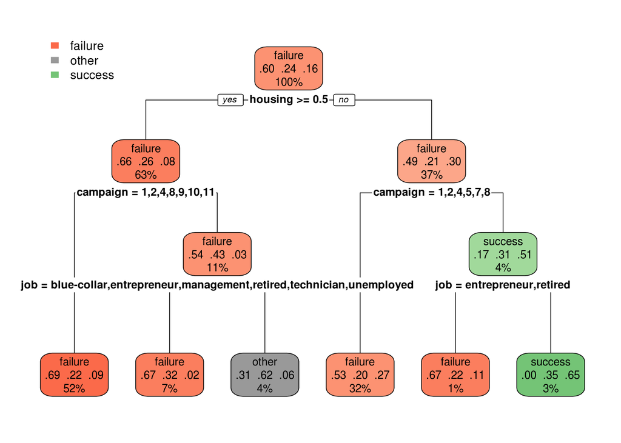

```r
rpart.plot::rpart.plot(poutcome_model)
```

### Inserindo os valores preditos na caracteristica ‘poutcome’

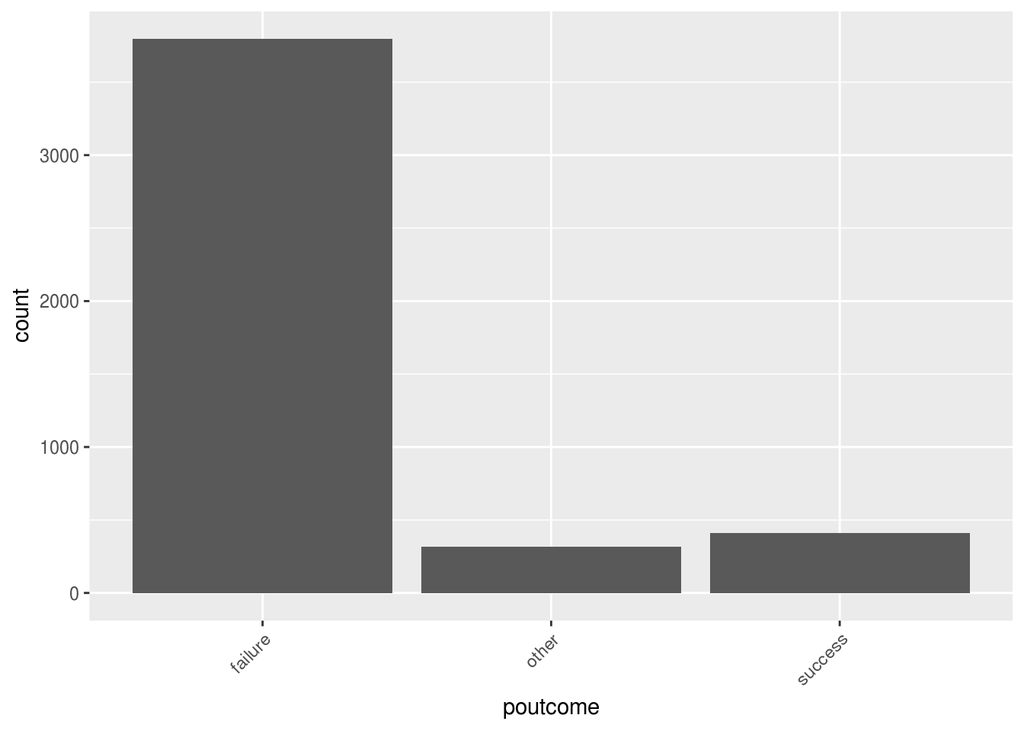

```r
dataset$poutcome[poutcome_unknown] <- poutcome_pred
dataset$poutcome <- droplevels(dataset$poutcome)
ggplot(dataset, aes(x=poutcome)) +
  geom_bar() +
  theme(axis.text.x = element_text(angle = 45, hjust = 1))
```

# Predição de Term

## Divisão em dois grupos: train and control

```r
set.seed(100)
pos <- sample(1:nrow(dataset), round(nrow(dataset)*0.1, 0))
dataset_train <- dataset[-pos,]
dataset_test <- dataset[pos,]
class <- dataset_test$term
dataset_test <- dataset_test[,!colnames(dataset_test)=='term']
```

### Naive bayes

Usando todas as caracteristicas categoricas

```r
# job
# marital
# education
# default
# housing
# loan
# contact
# day
# month
# campaign
# poutcome

m <- naive_bayes(term ~ duration +
                        job +
                        marital +
                        education +
                        default +
                        housing +
                        loan +
                        contact +
                        day +
                        month +
                        campaign +
                        poutcome, dataset_train)
```

```r
pred <- predict(m, dataset_test)
```

```r
confusion_matrix <- table(class, pred)
confusion_matrix
```

```
##        pred
## class   FALSE TRUE
##   FALSE   391   15
##   TRUE     29   17
```

```r
accuracy <- (confusion_matrix[2,2] + confusion_matrix[1,1]) / sum(confusion_matrix)
recall <- confusion_matrix[2,2] / (confusion_matrix[2,2] + confusion_matrix[2,1])
precision <- confusion_matrix[2,2] / (confusion_matrix[2,2] + confusion_matrix[1,2])

accuracy
```

```
## [1] 0.9026549
```

```r
recall
```

```
## [1] 0.3695652
```

```r
precision
```

```
## [1] 0.53125
```

### Decision tree

Selecionando as caracteristicas para o modelo.

```r
# job
# marital
# education
# default
# housing
# loan
# contact
# day
# month
# campaign
# poutcome
d <- dataset[, colnames(dataset) != 'y']
weights <- chi.squared(term ~ ., d)
print(weights)
```

```
##           attr_importance
## age           0.139874536
## job           0.118974056
## marital       0.064878796
## education     0.058893492
## default       0.001302653
## balance       0.085708896
## housing       0.104683400
## loan          0.070517035
## contact       0.139412818
## day           0.141898141
## month         0.235389272
## duration      0.410052810
## campaign      0.088226286
## pdays         0.272667383
## previous      0.162037684
## poutcome      0.148414055
```

```r
cutoff.k(weights, 5)
```

```
## [1] "duration" "pdays"    "month"    "previous" "poutcome"
```

```r
m2 <- rpart(term ~ duration +
                   # job +
                   # marital +
                   # education +
                   # default +
                   # housing +
                   # loan +
                   # contact +
                   # day +
                   month +
                   pdays +
                   previous +
                   # campaign +
                   poutcome,
                   dataset_train, method = 'class')
```

```r
pred2   <- predict(m2,  dataset_test,   type    =   "class")
```

```r
confusion_matrix <- table(class, pred2)
confusion_matrix
```

```
##        pred2
## class   FALSE TRUE
##   FALSE   385   21
##   TRUE     27   19
```

```r
accuracy <- (confusion_matrix[2,2] + confusion_matrix[1,1]) / sum(confusion_matrix)
recall <- confusion_matrix[2,2] / (confusion_matrix[2,2] + confusion_matrix[2,1])
precision <- confusion_matrix[2,2] / (confusion_matrix[2,2] + confusion_matrix[1,2])

accuracy
```

```
## [1] 0.8938053
```

```r
recall
```

```
## [1] 0.4130435
```

```r
precision
```

```
## [1] 0.475
```

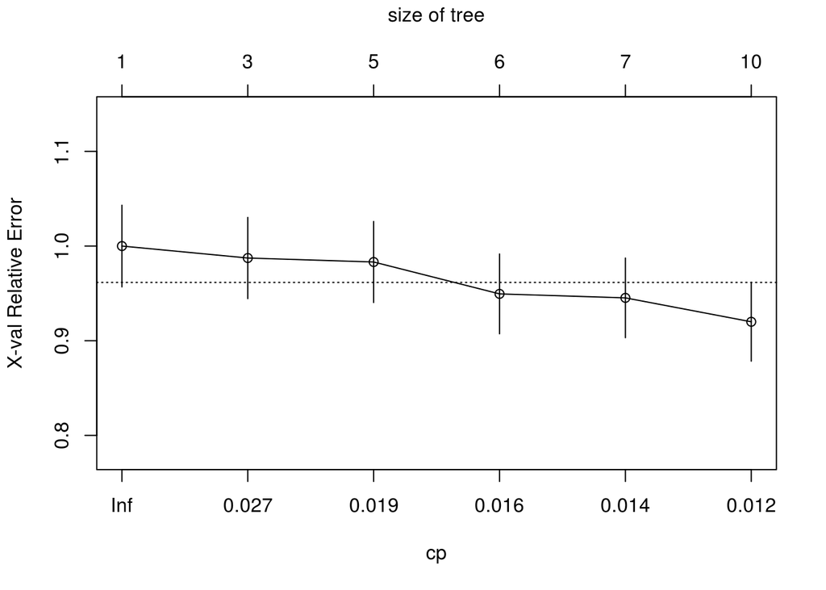

```r
plotcp(m2)
```

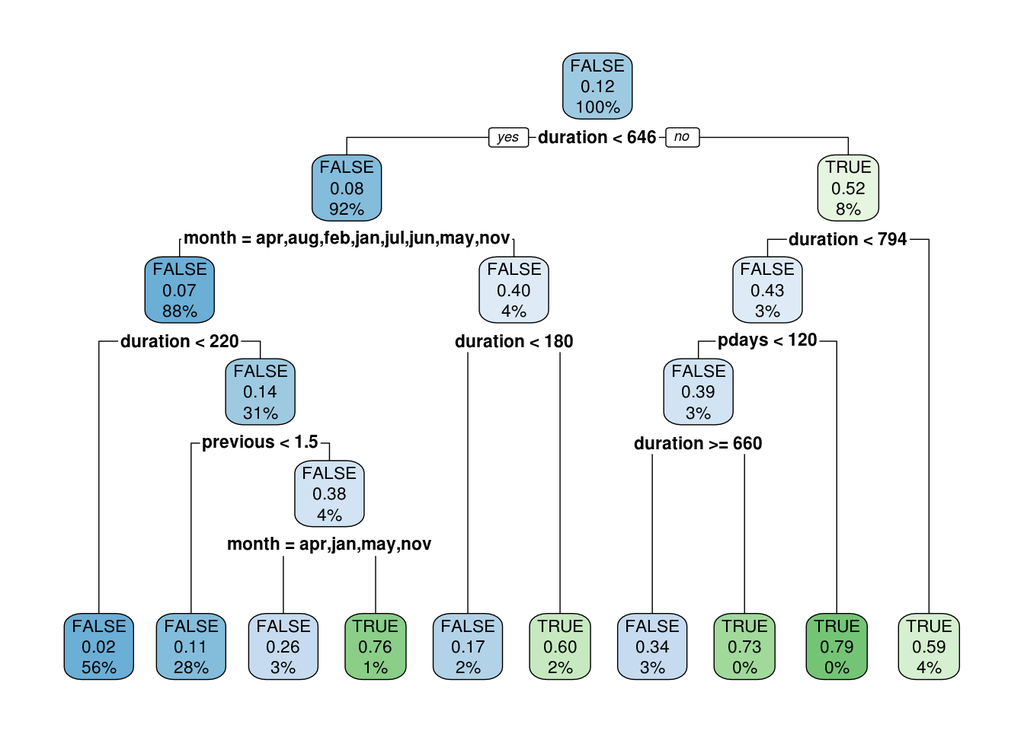

```r
rpart.plot::rpart.plot(m2)
```

Dado este resultado obtido com Decision Tree, podemos observar que o desbalanceamento da váriavel *term* (inicialmente chamada de *y*) causa um grande problema ao classificador. Temos uma alta acurácia, mas uma baixa cobertura com os Verdadeiro Positivos.

# Balanceamento

Abaixo iremos balancear este dado e vamos observar se temos uma melhora na predição.

```r
table(dataset$poutcome, dataset$term)
```

```
##
##           FALSE TRUE
##   failure  3427  370
##   other     271   44
##   success   302  107
```

```r
table(dataset_balanced$poutcome, dataset_balanced$term)
```

[output not shown]

```
##
##           FALSE TRUE
##   failure   427  370
##   other      30   44
##   success    43  107
```

# Predição

## Divisão em dois grupos: train and control

```r
set.seed(110)
pos <- sample(1:nrow(dataset_balanced), round(nrow(dataset_balanced)*0.1, 0))
dataset_train <- dataset_balanced[-pos,]
dataset_test <- dataset_balanced[pos,]
class <- dataset_test$term
dataset_test <- dataset_test[,!colnames(dataset_test)=='term']
```

### Decision tree

```r
m3 <- rpart(term ~ duration +
                   # job +
                   # marital +
                   # education +
                   # default +
                   # housing +
                   # loan +
                   # contact +
                   # day +
                   month +
                   pdays +
                   previous +
                   # campaign +
                   poutcome,
                   dataset_train, method = 'class')
```

```r
pred3   <- predict(m3,  dataset_test,   type    =   "class")
```

```r
confusion_matrix <- table(class, pred3)
confusion_matrix
```

```
##        pred3
## class   FALSE TRUE
##   FALSE    35   21
##   TRUE      6   40
```

```r
accuracy <- (confusion_matrix[1,1] + confusion_matrix[2,2]) / sum(confusion_matrix)
recall <- confusion_matrix[2,2] / (confusion_matrix[2,2] + confusion_matrix[2,1])
precision <- confusion_matrix[2,2] / (confusion_matrix[2,2] + confusion_matrix[1,2])

accuracy
```

```
## [1] 0.7352941
```

```r
recall
```

```
## [1] 0.8695652
```

```r
precision
```

```
## [1] 0.6557377
```

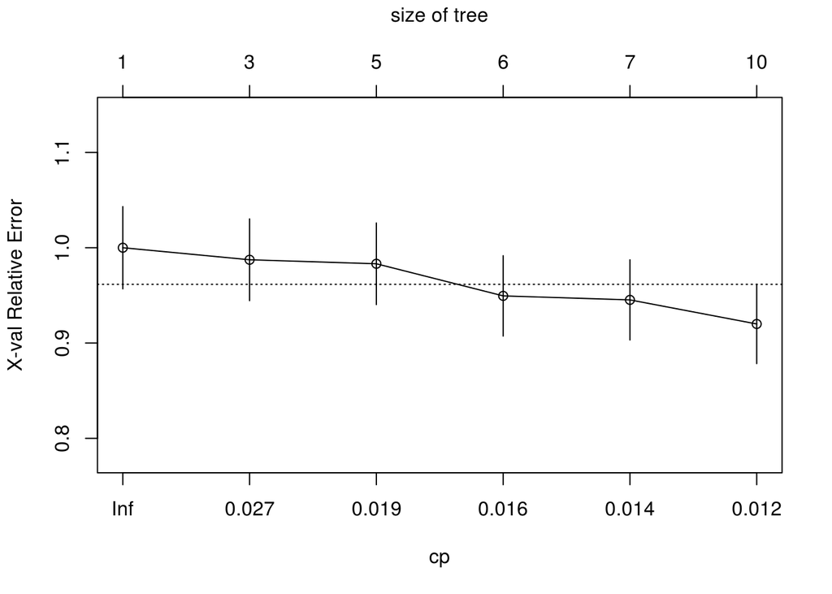

```r
plotcp(m2)
```

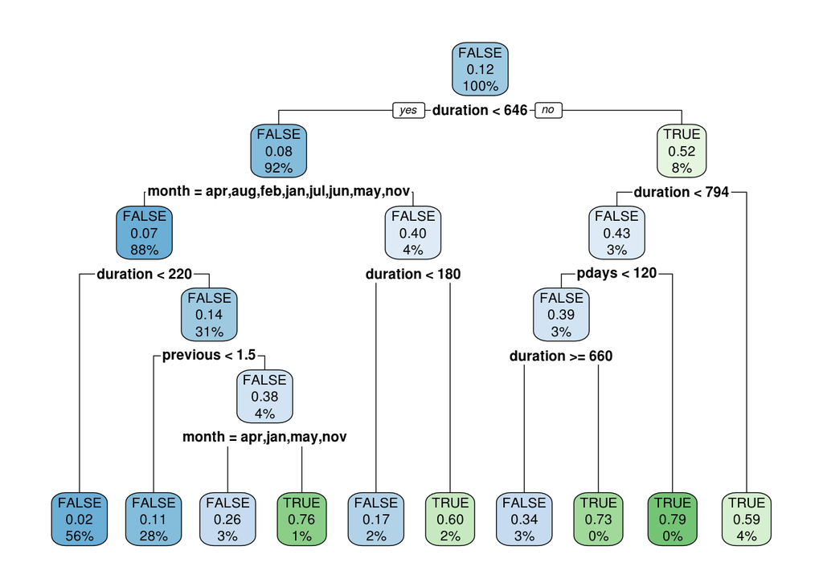

```r
rpart.plot::rpart.plot(m2)
```

Com o balanceamento conseguimos aumentar muito a cobertura dos Verdadeiros Positivos (0.8695652), tivemos uma queda na acurácia e um aumento na precisão. Este resultado pode ser mais refinado, melhorando a seleção de caracteristicas, o modelo e podando a arvore de decisão.